# Movement Analysis I

Author

Lejla Beganovic

# Introduction

Understanding how people move is relevant in many areas, from transportation planning to public health. In this task, GPS movement data from the GeoLife project (Zheng et al., 2011) is used to predict the transportation mode of individual GPS points recorded in Beijing. The dataset includes labelled trajectories from 73 users, covering modes such as walking, cycling, driving, bus, subway, and train.

The idea is to build a model that can infer the transport mode from movement parameters like speed, acceleration, and sinuosity, since this information is not directly measured by the GPS device. First, a minimal per-segment example is worked through, and then this is extended to per-point predictions.

# Minimal Example: Per-Segment Approach

## Step 1: Load the Data

```r
library(sf)
library(dplyr)

pfad <- "C:/Users/Lejlum/movement_analysis_I/Movement Analysis I-20260501"

training_dataset <- read_sf(file.path(pfad, "tracks_1.gpkg"), layer = "training") |>
  mutate(data = "training")
testing_dataset <- read_sf(file.path(pfad, "tracks_1.gpkg"), layer = "testing") |>
  mutate(data = "testing")
validation_dataset <- read_sf(file.path(pfad, "tracks_1.gpkg"), layer = "validation") |>
  mutate(data = "validation")

full_dataset <- bind_rows(training_dataset, testing_dataset, validation_dataset)

glimpse(full_dataset)
```

```
Rows: 1,004,732
Columns: 7
$ user_id  <int> 10, 10, 10, 10, 10, 10, 10, 10, 10, 10, 10, 10, 10, 10, 10, 1…
$ track_id <int> 95, 95, 95, 95, 95, 95, 95, 95, 95, 95, 95, 95, 95, 95, 95, 9…
$ datetime <dttm> 2008-06-18 16:47:35, 2008-06-18 16:47:37, 2008-06-18 16:47:3…
$ alt      <dbl> 161, 161, 161, 161, 161, 161, 161, 157, 157, 157, 157, 154, 1…
$ mode     <chr> "bus", "bus", "bus", "bus", "bus", "bus", "bus", "bus", "bus"…
$ data     <chr> "training", "training", "training", "training", "training", "…
$ geom     <POINT [m]> POINT (454778.1 4419210), POINT (454775 4419210), POINT…
```

Let’s first get an overview of where the data was collected.

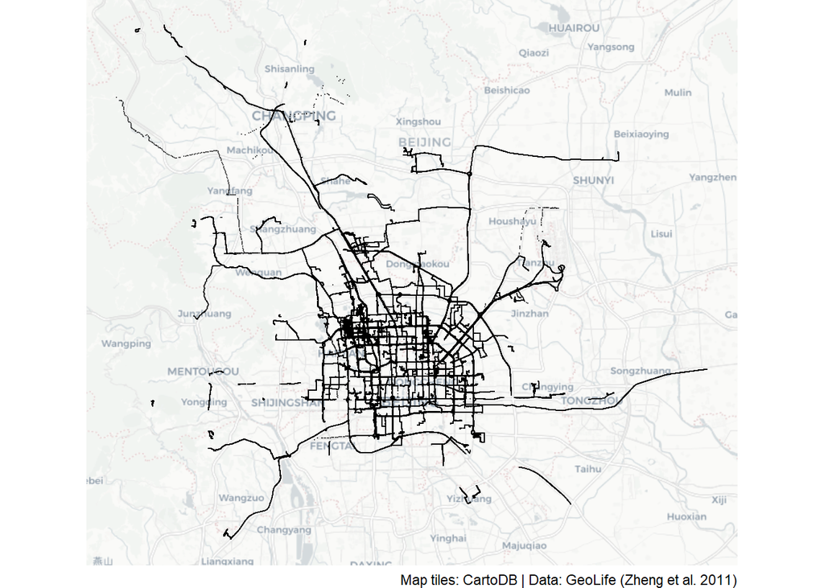

```r
library(ggplot2)
library(ggspatial)

ggplot() +
  annotation_map_tile(type = "cartolight", zoom = 10, quiet = TRUE) +
  geom_sf(data = full_dataset, size = 0.05, alpha = 0.5) +
  theme_void() +
  labs(caption = "Map tiles: CartoDB | Data: GeoLife (Zheng et al. 2011)")
```

The trajectories are spread across the greater Beijing area, with most of them concentrated in the city centre. This makes sense given that the data comes from everyday urban movement.

## Step 2: Feature Engineering

To be able to predict the transport mode, we first need to create features that describe how someone is moving. Here, three movement parameters are computed: speed, acceleration, and sinuosity. These are derived from the spatial and temporal relationships between consecutive GPS points within each trajectory.

### Speed

Speed is simply the distance between two consecutive points divided by the time between them.

```r
full_dataset <- full_dataset |>
  mutate(
    steplength = as.numeric(st_distance(lead(geom), geom, by_element = TRUE)),
    timelag    = as.numeric(difftime(lead(datetime), datetime, units = "secs")),
    speed      = steplength / timelag,
    .by = track_id
  )
```

To get a sense of how speed differs between modes, the mean speed per segment is visualized as a boxplot.

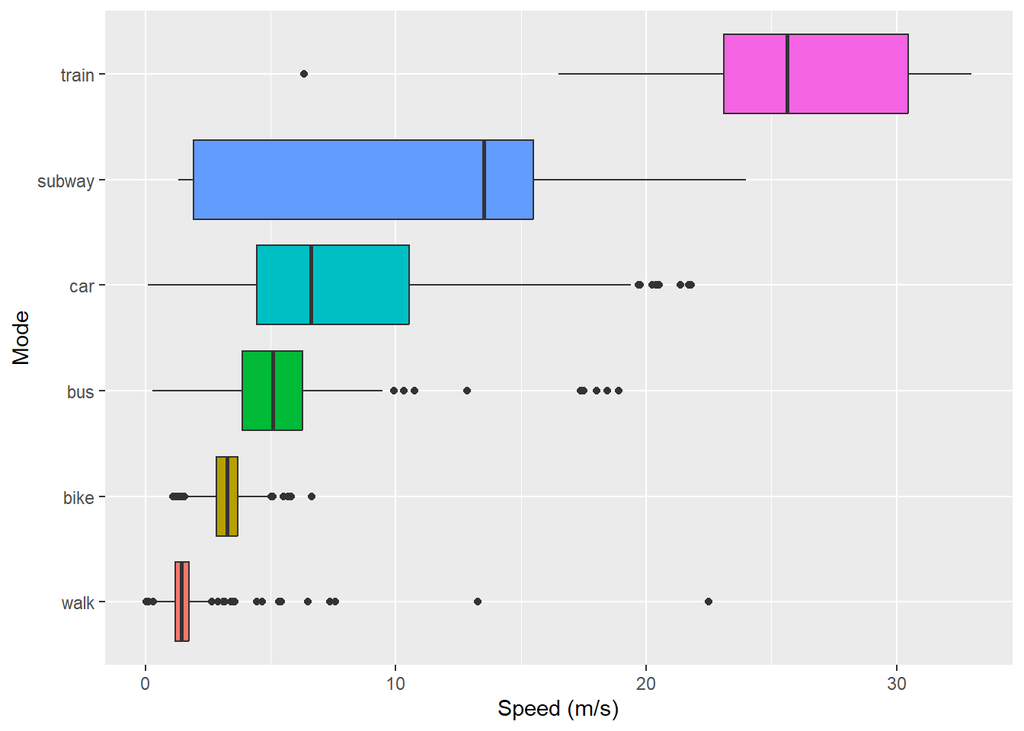

Figure 1: Average speed per segment for different transportation modes.

```r
library(forcats)

full_dataset |>
  st_drop_geometry() |>
  filter(!is.na(mode)) |>
  summarise(
    speed = mean(speed, na.rm = TRUE),
    .by = c(mode, track_id)
  ) |>
  mutate(mode = fct_reorder(mode, speed)) |>
  ggplot() +
  geom_boxplot(aes(speed, mode, fill = mode)) +
  theme(legend.position = "none") +
  labs(x = "Speed (m/s)", y = "Mode")
```

Figure 1 shows that speed differs quite clearly between the modes. Walking and cycling are the slowest, while train is by far the fastest. Bus and car have overlapping speed ranges, which already suggests that speed alone will not be enough to tell them apart. This is also why additional features like sinuosity and acceleration are needed.

### Acceleration

Acceleration describes how quickly the speed changes over time. Modes like walking and cycling tend to have more frequent speed changes, while driving or taking the train is usually smoother.

```r
full_dataset <- full_dataset |>
  mutate(
    acceleration = (lead(speed) - speed) / timelag,
    .by = track_id
  )
```

### Sinuosity

Sinuosity describes how curved a path is. A perfectly straight path has a sinuosity of 1, and more winding paths have higher values. Here, sinuosity is computed over a 5-point window, by comparing the total distance traveled to the straight-line distance between the start and end of the window.

```r
library(zoo)

full_dataset <- full_dataset |>
  mutate(
    straight_dist5 = as.numeric(st_distance(lead(geom, 5), geom, by_element = TRUE)),
    full_dist5     = rollsum(steplength, 5, fill = NA, align = "left"),
    sinuosity      = full_dist5 / straight_dist5,
    .by = track_id
  )
```

## Step 3: Training a Model

For this first model, the point-level features are aggregated per segment using the mean, maximum, and minimum. A CART decision tree is trained because it is easy to interpret and gives a good starting point.

```r
mean2 <- \(x) mean(x, na.rm = TRUE)
max2  <- \(x) max(x,  na.rm = TRUE)
min2  <- \(x) min(x,  na.rm = TRUE)

tracks_smry <- full_dataset |>
  st_drop_geometry() |>
  select(data, track_id, mode, steplength, timelag, speed, sinuosity) |>
  group_by(data, track_id, mode) |>
  summarise(
    across(
      c(steplength, timelag, speed, sinuosity),
      list(mean = mean2, max = max2, min = min2)
    )
  ) |>
  mutate(mode = factor(mode)) |>
  ungroup() |>
  select(-track_id)

tracks_training   <- tracks_smry |> filter(data == "training")   |> select(-data)
tracks_testing    <- tracks_smry |> filter(data == "testing")    |> select(-data)
tracks_validation <- tracks_smry |> filter(data == "validation") |> select(-data)
```

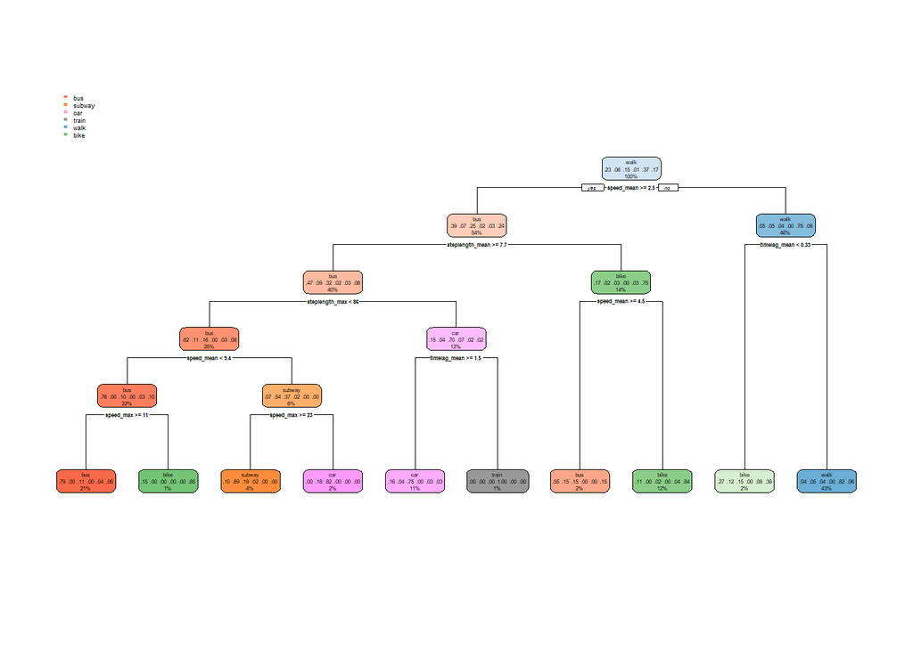

Figure 2: Decision tree trained on segment-level movement features.

```r
library(rpart)
library(rpart.plot)

cart_model <- rpart(mode ~ ., data = tracks_training, method = "class")

rpart.plot(cart_model, type = 2)
```

## Step 4: Evaluating the Model

```r
library(caret)

predictions <- predict(cart_model, tracks_testing)

tracks_testing$prediction <- colnames(predictions)[apply(predictions, 1, which.max)]
tracks_testing$prediction <- factor(tracks_testing$prediction)

tracks_testing$mode <- factor(
  tracks_testing$mode,
  levels = sort(unique(as.character(tracks_testing$mode)))
)

confusionMatrix(tracks_testing$prediction, reference = tracks_testing$mode)
```

```
Confusion Matrix and Statistics

          Reference
Prediction bike bus car subway train walk
    bike     68  20   2      1     0    3
    bus      21  91  25      4     1   11
    car       1  18  42      8     0    1
    subway    0   0   8     18     1    0
    train     0   0   0      1     4    0
    walk     11  17   6     12     0  166

Overall Statistics

               Accuracy : 0.6934
                 95% CI : (0.6534, 0.7313)
    No Information Rate : 0.3226
    P-Value [Acc > NIR] : < 2.2e-16

                  Kappa : 0.5937

 Mcnemar's Test P-Value : NA

Statistics by Class:

                     Class: bike Class: bus Class: car Class: subway
Sensitivity               0.6733     0.6233    0.50602       0.40909
Specificity               0.9435     0.8506    0.94142       0.98259
Pos Pred Value            0.7234     0.5948    0.60000       0.66667
Neg Pred Value            0.9293     0.8652    0.91650       0.95131
Prevalence                0.1800     0.2602    0.14795       0.07843
Detection Rate            0.1212     0.1622    0.07487       0.03209
Detection Prevalence      0.1676     0.2727    0.12478       0.04813
Balanced Accuracy         0.8084     0.7369    0.72372       0.69584
                     Class: train Class: walk
Sensitivity              0.666667      0.9171
Specificity              0.998198      0.8789
Pos Pred Value           0.800000      0.7830
Neg Pred Value           0.996403      0.9570
Prevalence               0.010695      0.3226
Detection Rate           0.007130      0.2959
Detection Prevalence     0.008913      0.3779
Balanced Accuracy        0.832432      0.8980
```

The model reaches an overall accuracy of about 69%. Walking is classified quite well, with a sensitivity of 0.92, which makes sense given how different its speed is from all other modes. Train has a sensitivity of 0.67, which is moderate, but its specificity is very high (0.998), meaning almost nothing is wrongly predicted as train. The biggest problems are with bus and car: bus only reaches 62% sensitivity and car only 51%. This is likely because both modes have similar speeds in city traffic and it is hard to separate them based on movement alone.

## Step 5: Predicting the Validation Data

```r
predictions_validation <- predict(cart_model, tracks_validation)

tracks_validation$prediction <- colnames(predictions_validation)[
  apply(predictions_validation, 1, which.max)
]
tracks_validation$prediction <- factor(tracks_validation$prediction)

cat("Predicted class distribution in validation set:\n")
```

```
Predicted class distribution in validation set:
```

```r
print(table(tracks_validation$prediction))
```

```
  bike    bus    car subway  train   walk
    80    134     88     20      3    193
```

The predicted distribution in the validation set looks similar to what was seen in the training data, which suggests the model is not overfitting too much.

# Extension: Per-Point Predictions

In the minimal example, features were aggregated per segment before training. The actual goal of this task is to predict the transport mode for every individual GPS point. This is harder because single points are noisier, but it gives more detailed predictions.

## Feature Engineering at the Point Level

In addition to speed, acceleration, and sinuosity, a turning angle feature is added here. The turning angle measures the direction change between consecutive steps, which helps distinguish walking and cycling (more turning) from motorised modes (generally smoother).

```r
full_dataset <- full_dataset |>
  mutate(
    dx = as.numeric(lead(st_coordinates(geom)[, 1]) - st_coordinates(geom)[, 1]),
    dy = as.numeric(lead(st_coordinates(geom)[, 2]) - st_coordinates(geom)[, 2]),
    .by = track_id
  )

full_dataset <- full_dataset |>
  mutate(
    azi_next   = atan2(dy, dx),
    azi_prev   = lag(azi_next),
    turn_angle = atan2(sin(azi_next - azi_prev), cos(azi_next - azi_prev)),
    .by = track_id
  )
```

## Preparing Point-Level Training and Testing Data

No aggregation is applied here. Each row is one GPS point with its own feature values. Points at segment boundaries where features cannot be computed are removed.

```r
feat_cols <- c("speed", "acceleration", "sinuosity", "turn_angle")

point_data <- full_dataset |>
  st_drop_geometry() |>
  select(data, mode, all_of(feat_cols)) |>
  filter(if_all(all_of(feat_cols), ~ is.finite(.)))

point_train <- point_data |>
  filter(data == "training", !is.na(mode)) |>
  select(-data) |>
  mutate(mode = factor(mode))

point_test <- point_data |>
  filter(data == "testing", !is.na(mode)) |>
  select(-data) |>
  mutate(mode = factor(mode))

cat("Training points:", nrow(point_train), "\n")
```

```
Training points: 398342
```

```r
cat("Testing points:", nrow(point_test), "\n")
```

```
Testing points: 214793
```

```r
cat("Class distribution:\n")
```

```
Class distribution:
```

```r
print(table(point_train$mode))
```

```
  bike    bus    car subway  train   walk
 75311 123943  50791  17274   3014 128009
```

## Model Selection: Random Forest

A Random Forest is chosen for the per-point model. It works better than a single decision tree on noisy data because it combines many trees and averages their predictions, which reduces the risk of overfitting.

```r
library(ranger)

set.seed(42)

point_sample <- point_train |>
  group_by(mode) |>
  slice_sample(n = 8000, replace = TRUE) |>
  ungroup()

rf_model <- ranger(
  formula        = mode ~ speed + acceleration + sinuosity + turn_angle,
  data           = point_sample,
  num.trees      = 300,
  importance     = "impurity",
  classification = TRUE,
  seed           = 42
)

print(rf_model)
```

```
Ranger result

Call:
 ranger(formula = mode ~ speed + acceleration + sinuosity + turn_angle,      data = point_sample, num.trees = 300, importance = "impurity",      classification = TRUE, seed = 42)

Type:                             Classification
Number of trees:                  300
Sample size:                      48000
Number of independent variables:  4
Mtry:                             2
Target node size:                 1
Variable importance mode:         impurity
Splitrule:                        gini
OOB prediction error:             35.76 %
```

## Evaluation on Testing Data

```r
pred_rf <- predict(rf_model, data = point_test)$predictions

pred_rf         <- factor(pred_rf,         levels = sort(levels(point_test$mode)))
point_test$mode <- factor(point_test$mode, levels = sort(levels(point_test$mode)))

confusionMatrix(pred_rf, reference = point_test$mode)
```

```
Confusion Matrix and Statistics

          Reference
Prediction  bike   bus   car subway train  walk
    bike   28058 11718  3523    614   130  7800
    bus     4736 25832  6812   1177   525  6199
    car     1733  9973  8956   1011   519  1668
    subway   627  2781  4456   6841   555  2480
    train     94  1592  2563    984  1249   133
    walk    8130 17431  3691   2605    78 37519

Overall Statistics

               Accuracy : 0.5049
                 95% CI : (0.5028, 0.507)
    No Information Rate : 0.3228
    P-Value [Acc > NIR] : < 2.2e-16

                  Kappa : 0.3638

 Mcnemar's Test P-Value : < 2.2e-16

Statistics by Class:

                     Class: bike Class: bus Class: car Class: subway
Sensitivity               0.6468     0.3726     0.2985       0.51700
Specificity               0.8612     0.8663     0.9193       0.94593
Pos Pred Value            0.5412     0.5705     0.3754       0.38563
Neg Pred Value            0.9060     0.7434     0.8898       0.96757
Prevalence                0.2020     0.3228     0.1397       0.06160
Detection Rate            0.1306     0.1203     0.0417       0.03185
Detection Prevalence      0.2414     0.2108     0.1111       0.08259
Balanced Accuracy         0.7540     0.6195     0.6089       0.73147
                     Class: train Class: walk
Sensitivity              0.408704      0.6724
Specificity              0.974657      0.7991
Pos Pred Value           0.188813      0.5402
Neg Pred Value           0.991320      0.8742
Prevalence               0.014228      0.2598
Detection Rate           0.005815      0.1747
Detection Prevalence     0.030797      0.3234
Balanced Accuracy        0.691681      0.7358
```

## Feature Importance

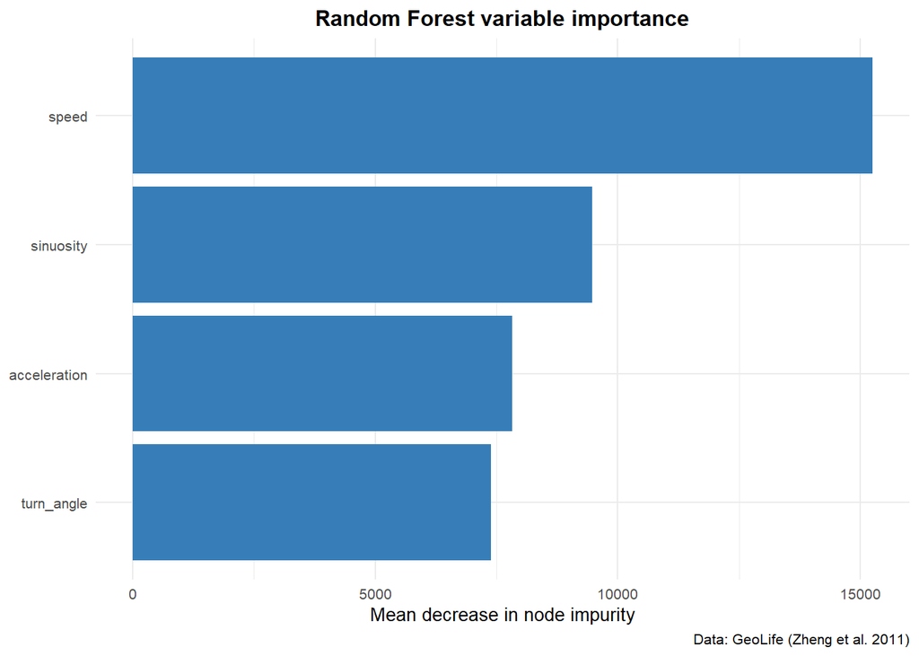

Figure 3: Variable importance from the Random Forest model.

```r
importance_df <- data.frame(
  feature    = names(rf_model$variable.importance),
  importance = rf_model$variable.importance
) |>
  arrange(desc(importance))

ggplot(importance_df, aes(x = reorder(feature, importance), y = importance)) +
  geom_col(fill = "#377eb8") +
  coord_flip() +
  labs(
    title   = "Random Forest variable importance",
    x       = NULL,
    y       = "Mean decrease in node impurity",
    caption = "Data: GeoLife (Zheng et al. 2011)"
  ) +
  theme_minimal(base_size = 10) +
  theme(plot.title = element_text(face = "bold", hjust = 0.5))
```

## Predicting the Validation Dataset

```r
point_val <- full_dataset |>
  st_drop_geometry() |>
  filter(data == "validation") |>
  select(all_of(feat_cols)) |>
  filter(if_all(all_of(feat_cols), ~ is.finite(.)))

point_val$predicted_mode <- predict(rf_model, data = point_val)$predictions

cat("Predicted class distribution in validation set:\n")
```

```
Predicted class distribution in validation set:
```

```r
print(table(point_val$predicted_mode))
```

```
  bike    bus    car subway  train   walk
 42860  35482  20636  12437   4171  64903
```

## Discussion

The per-point Random Forest model reaches a lower overall accuracy than the per-segment CART baseline (50.5% vs. 69%), which is expected since individual GPS points are much noisier than aggregated segment features. Speed is the most important predictor, which matches expectations since different transport modes have very different velocity ranges. Sinuosity helps to further distinguish between modes with similar speeds, for example walking versus cycling. Acceleration and turning angle add additional information, especially for separating bus from car and walking from cycling.

The biggest remaining challenge is the confusion between bus, car, and subway. In dense city traffic, all three can have similar speeds and path shapes, which makes them hard to tell apart from movement features alone. GPS noise also affects the results, particularly for acceleration and turning angle, which are sensitive to measurement errors especially at low speeds.

To improve the model further, one could try using a larger window for sinuosity, adding the time of day as a feature, or including information from the road network, as discussed in the Context-Aware Movement Analysis (CMA2) lecture.

## References

Zheng, Yu, Hao Fu, Xing Xie, Wei-Ying Ma, and Quannan Li. 2011. *Geolife GPS Trajectory Dataset - User Guide*. Geolife GPS trajectories 1.1. https://www.microsoft.com/en-us/research/publication/geolife-gps-trajectory-dataset-user-guide/

# Declaration of AI Use

In accordance with the ZHAW Z-RL-Guidelines on AI in assessments (01.04.2023), I declare that I used Claude (Anthropic) as an AI assistant during this assignment.

Claude supported me with debugging errors, correcting text phrasing, and structuring the feature engineering pipeline and classification workflow in this task.

All decisions about structure, approach, and content were made by me. I understood each correction before applying it, and Claude served as a troubleshooting and learning aid rather than a replacement for my own work.